# Assignment 1: MATH 4753

## 7-MS Statistics In Action

### a.

The data collection method is a designed experiment with a stratified sample. The different locations where specimens of fish were collected represent the strata for this study.

### b.

The population for this study is not the sum of all the fish specimens that were obtained but rather the total number of fish in the Tennessee River and its various tributaries.

### c.

The names of all the qualitative variables are “MILE”, “RIVER”, and “SPECIES”.

## 8-Do Social Robots Walk or Roll?

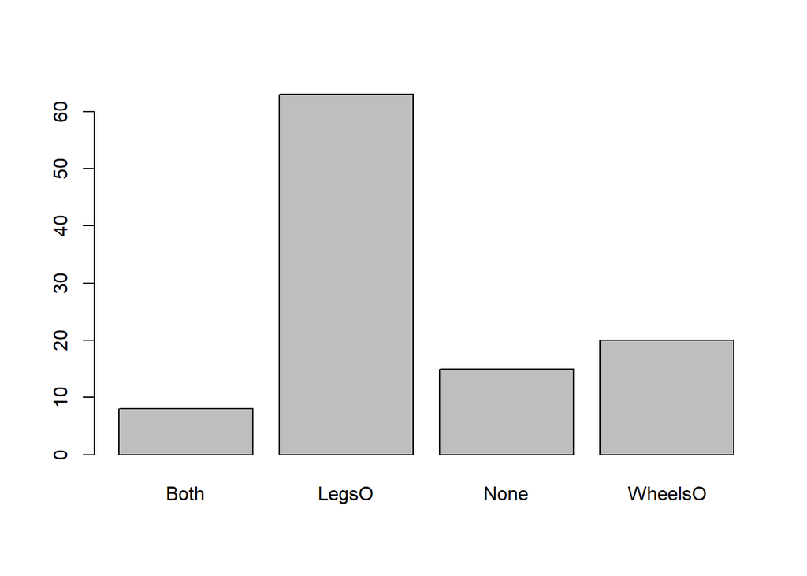

```r
freq=c(15,8,63,20)
RL=c("None","Both","LegsO","WheelsO")
l=rep(RL,freq)
lt = table(l)
barplot(lt)
```

### a.

A barplot is used to describe the data.

### c.

Legs only is the robot design that is currently most used.

### d.

The class frequencies for each category are as follows: None: 0.1415, Both: 0.0755, Legs ONLY: 0.5943, Wheels ONLY: 0.1887.

### e.

Pareto Diagram

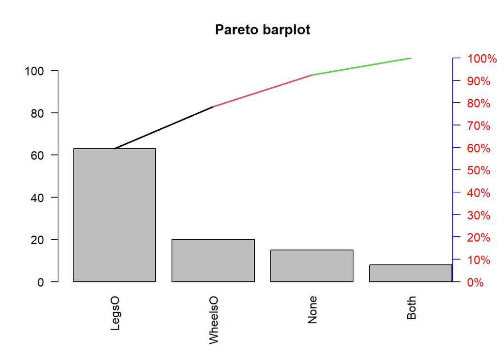

```r
pareto<-function(x,mn="Pareto barplot",...){  # x is a vector
x.tab=table(x)
xx.tab=sort(x.tab, decreasing=TRUE,index.return=FALSE)
cumsum(as.vector(xx.tab))->cs
length(x.tab)->lenx
bp<-barplot(xx.tab,ylim=c(0,max(cs)),las=2)
lb<-seq(0,cs[lenx],l=11)
axis(side=4,at=lb,labels=paste(seq(0,100,length=11),"%",sep=""),las=1,line=-1,col="Blue",col.axis="Red")
for(i in 1:(lenx-1)){
segments(bp[i],cs[i],bp[i+1],cs[i+1],col=i,lwd=2)
}
title(main=mn,...)

}

pareto(l)
```

## 9-Microsoft Program Security Issues

### a.

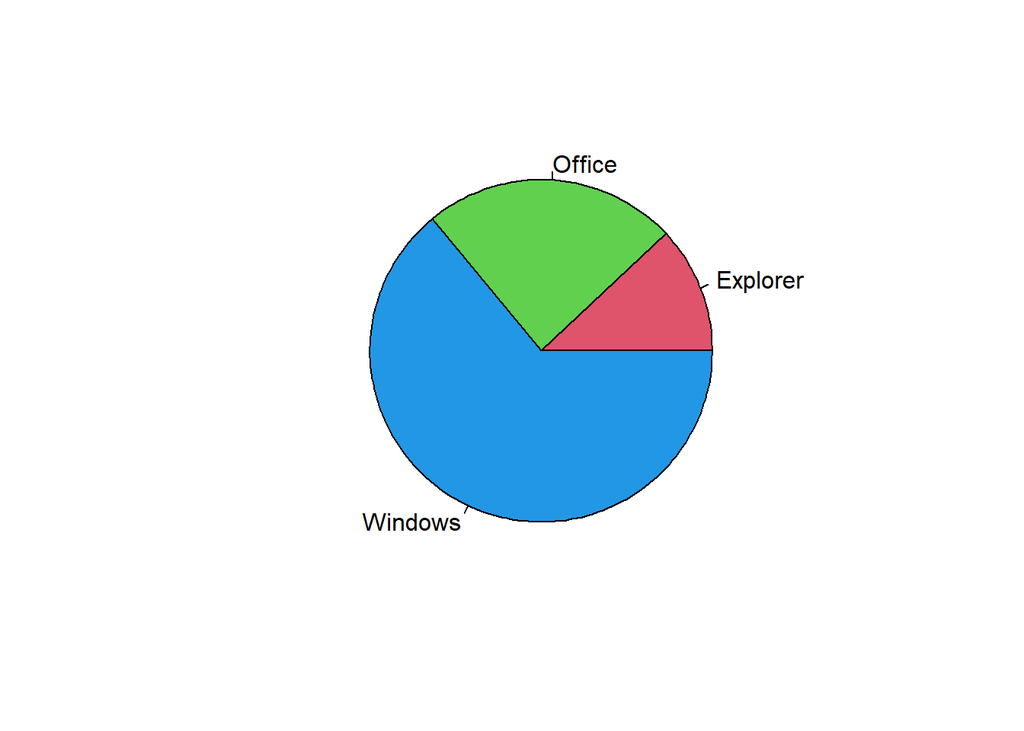

```r
freq1=c(32,6,12)
products=c("Windows","Explorer","Office")
mp=rep(products,freq1)
mpt = table(mp)
pie(mpt, col = 2:4)
```

Explorer was the Microsoft product with the lowest proportion of security issues in 2012.

### b.

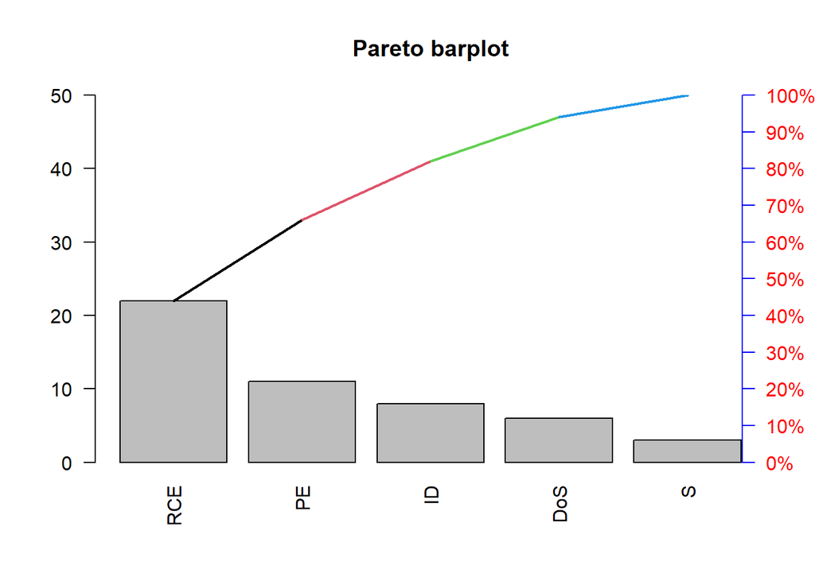

```r
freq2=c(6,8,22,3,11)
repercuss=c("DoS","ID","RCE", "S", "PE")
mr=rep(repercuss,freq2)
pareto(mr)
```

Based on the graph, I would advise Microsoft to focus on remote code execution.